# MDI343 TP - APPRENTISSAGE NON SUPERVISÉ, ANALYSE EXPLORATOIRE - ACP, AC ACM

Dans ce TP on met en oeuvre les techniques de l’analyse en composantes principales (ACP), de l’analyse des correspondances (AC) et de l’analyse des correspondances multiples (ACM), à l’aide du package `FactoMineR`. On utilisera également un jeu de données du package `ade4`.

```r
library(ade4)
library(FactoMineR)
```

#### **Exercice 1** (Analyse en composantes principales des températures de villes d’europe).

Téléchargez les données `temperature`.

```r
temperature <-
read.table("http://factominer.free.fr/book/temperature.csv",
header=TRUE,sep=";",dec=".",row.names=1)
```

Le jeu de données contient les températures mensuelles moyennes de différentes villes. Les moyennes et amplitudes annuelles sont indiquées en plus, ainsi que les coordonnées géographiques (latitude, longitude). Une variable qualitative indique l’aire géographique (nord, sud, est, ouest). L’objectif ici est de dresser une typologie des villes en utilisant seulement les températures mensuelles et de valider l’analyse ensuite avec les variables supplémentaires. Les commandes suivantes permettent d’inspecter les caractéristiques principales du jeu de données.

```r
class(temperature)
```

```
[1] "data.frame"
```

```r
names(temperature)
```

```
 [1] "January"   "February"  "March"     "April"     "May"
 [6] "June"      "July"      "August"    "September" "October"
[11] "November"  "December"  "Annual"    "Amplitude" "Latitude"
[16] "Longitude" "Area"
```

```r
rownames(temperature)
```

```
 [1] "Amsterdam "      "Athens "         "Berlin "
 [4] "Brussels"        "Budapest "       "Copenhagen "
 [7] "Dublin "         "Elsinki"         "Kiev "
[10] "Krakow "         "Lisbon "         "London "
[13] "Madrid "         "Minsk "          "Moscow"
[16] "Oslo "           "Paris "          "Prague "
[19] "Reykjavik "      "Rome "           "Sarajevo "
[22] "Sofia "          "Stockholm "      "Antwerp "
[25] "Barcelona "      "Bordeaux "       "Edinburgh "
[28] "Frankfurt "      "Geneva "         "Genoa "
[31] "Milan "          "Palermo "        "Seville "
[34] "St. Petersburg " "Zurich "
```

```r
dim(temperature)
```

```
[1] 35 17
```

```r
plot(as.numeric(temperature[1, 1:12]), ylim=range(temperature[,1:12]))
lines(as.numeric(temperature[2,1:12]))
```

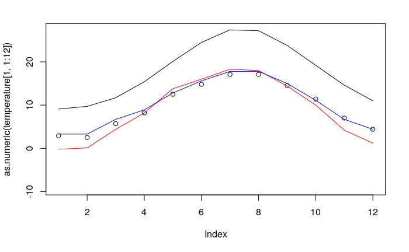

```r
lines(as.numeric(temperature[3,1:12]), col="red")
lines(as.numeric(temperature[4,1:12]), col="blue")
```

La commande suivante effectue l’ACP du jeu de données. les individus 24 à 35 sont passés en individus supplémentaires (pas des capitales). On passe en variables supplémentaires toutes les variables qui ne sont pas des moyennes mensuelles. Par défaut la fonction PCA centre et réduit les colonnes ( `scale.unit = TRUE` ).

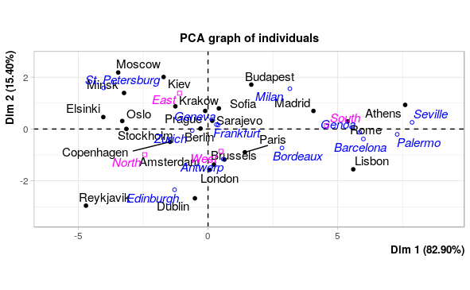

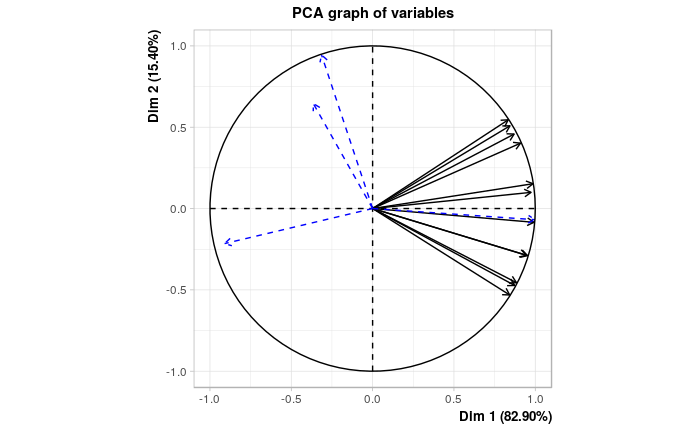

```r
res <- PCA(temperature,ind.sup=24:35,quanti.sup=13:16,quali.sup=17)
```

Pour fermer toutes les fenêtres graphiques : `graphics.off()` . Pour passer en revue ce que fait la fonction PCA et inspecter le résultat :

```r
?PCA
names(res)
```

```
[1] "eig"        "var"        "ind"        "svd"        "ind.sup"    "quanti.sup"
[7] "quali.sup"  "call"
```

**N.B.** pour accéder aux éléments d’une liste on utilise le symbole $ : par exemple

```r
res$call
```

```
$row.w
 [1] 0.04347826 0.04347826 0.04347826 0.04347826 0.04347826 0.04347826 0.04347826
 [8] 0.04347826 0.04347826 0.04347826 0.04347826 0.04347826 0.04347826 0.04347826
[15] 0.04347826 0.04347826 0.04347826 0.04347826 0.04347826 0.04347826 0.04347826
[22] 0.04347826 0.04347826

$col.w
 [1] 1 1 1 1 1 1 1 1 1 1 1 1

$scale.unit
[1] TRUE

$ncp
[1] 5

$centre
 [1]  0.1739130  0.9565217  4.0608696  8.3782609 13.2739130 16.7652174 18.9260870
 [8] 18.3043478 14.7086957 10.0652174  5.0782609  1.8434783

$ecart.type
 [1] 5.066447 5.008152 4.392854 3.395260 2.958733 3.069855 3.328822 3.526111 3.681790
[10] 3.869795 4.135841 4.515079

$X
```

|  | January | February | March | April | May | June | July | August | September | October | November | December | Annual | Amplitude | Latitude | Longitude | Area |
| --- | --- | --- | --- | --- | --- | --- | --- | --- | --- | --- | --- | --- | --- | --- | --- | --- | --- |
| Amsterdam | 2.9 | 2.5 | 5.7 | 8.2 | 12.5 | 14.8 | 17.1 | 17.1 | 14.5 | 11.4 | 7.0 | 4.4 | 9.9 | 14.6 | 52.2 | 4.5 | West |
| Athens | 9.1 | 9.7 | 11.7 | 15.4 | 20.1 | 24.5 | 27.4 | 27.2 | 23.8 | 19.2 | 14.6 | 11.0 | 17.8 | 18.3 | 37.6 | 23.5 | South |
| Berlin | -0.2 | 0.1 | 4.4 | 8.2 | 13.8 | 16.0 | 18.3 | 18.0 | 14.4 | 10.0 | 4.2 | 1.2 | 9.1 | 18.5 | 52.3 | 13.2 | West |
| Brussels | 3.3 | 3.3 | 6.7 | 8.9 | 12.8 | 15.6 | 17.8 | 17.8 | 15.0 | 11.1 | 6.7 | 4.4 | 10.3 | 14.4 | 50.5 | 4.2 | West |
| Budapest | -1.1 | 0.8 | 5.5 | 11.6 | 17.0 | 20.2 | 22.0 | 21.3 | 16.9 | 11.3 | 5.1 | 0.7 | 10.9 | 23.1 | 47.3 | 19.0 | East |
| Copenhagen | -0.4 | -0.4 | 1.3 | 5.8 | 11.1 | 15.4 | 17.1 | 16.6 | 13.3 | 8.8 | 4.1 | 1.3 | 7.8 | 17.5 | 55.4 | 12.3 | North |
| Dublin | 4.8 | 5.0 | 5.9 | 7.8 | 10.4 | 13.3 | 15.0 | 14.6 | 12.7 | 9.7 | 6.7 | 5.4 | 9.3 | 10.2 | 53.2 | 6.1 | North |
| Elsinki | -5.8 | -6.2 | -2.7 | 3.1 | 10.2 | 14.0 | 17.2 | 14.9 | 9.7 | 5.2 | 0.1 | -2.3 | 4.8 | 23.4 | 60.1 | 25.0 | North |
| Kiev | -5.9 | -5.0 | -0.3 | 7.4 | 14.3 | 17.8 | 19.4 | 18.5 | 13.7 | 7.5 | 1.2 | -3.6 | 7.1 | 25.3 | 50.3 | 30.3 | East |
| Krakow | -3.7 | -2.0 | 1.9 | 7.9 | 13.2 | 16.9 | 18.4 | 17.6 | 13.7 | 8.6 | 2.6 | -1.7 | 7.7 | 22.1 | 50.0 | 19.6 | East |

[output cut: 25 more lines]

```
$row.w.init
 [1] 1 1 1 1 1 1 1 1 1 1 1 1 1 1 1 1 1 1 1 1 1 1 1

$call
PCA(X = temperature, ind.sup = 24:35, quanti.sup = 13:16, quali.sup = 17)

$ind.sup
 [1] 24 25 26 27 28 29 30 31 32 33 34 35

$quanti.sup
```

|  | Annual | Amplitude | Latitude | Longitude |
| --- | --- | --- | --- | --- |
| Amsterdam | 9.9 | 14.6 | 52.2 | 4.5 |
| Athens | 17.8 | 18.3 | 37.6 | 23.5 |
| Berlin | 9.1 | 18.5 | 52.3 | 13.2 |
| Brussels | 10.3 | 14.4 | 50.5 | 4.2 |
| Budapest | 10.9 | 23.1 | 47.3 | 19.0 |
| Copenhagen | 7.8 | 17.5 | 55.4 | 12.3 |
| Dublin | 9.3 | 10.2 | 53.2 | 6.1 |
| Elsinki | 4.8 | 23.4 | 60.1 | 25.0 |
| Kiev | 7.1 | 25.3 | 50.3 | 30.3 |
| Krakow | 7.7 | 22.1 | 50.0 | 19.6 |

[output cut: 13 more lines]

```
$quali.sup
$quali.sup$quali.sup
```

|  | Area |
| --- | --- |
| Amsterdam | West |
| Athens | South |
| Berlin | West |
| Brussels | West |
| Budapest | East |
| Copenhagen | North |
| Dublin | North |
| Elsinki | North |
| Kiev | East |
| Krakow | East |

[output cut: 13 more lines]

```
$quali.sup$modalite
[1] 4

$quali.sup$nombre
[1] 7 7 5 4

$quali.sup$barycentre
```

|  | January | February | March | April | May | June | July | August | September | October | November | December |
| --- | --- | --- | --- | --- | --- | --- | --- | --- | --- | --- | --- | --- |
| East | -4.2714286 | -2.8000000 | 1.585714 | 8.114286 | 14.071429 | 17.52857 | 19.25714 | 18.37143 | 13.97143 | 8.342857 | 2.385714 | -1.9857143 |
| North | -0.8714286 | -0.6571429 | 1.271429 | 5.114286 | 9.942857 | 13.80000 | 15.91429 | 14.94286 | 11.48571 | 7.228571 | 3.014286 | 0.6428571 |
| South | 6.0600000 | 7.3200000 | 9.860000 | 13.020000 | 16.880000 | 20.68000 | 23.38000 | 23.24000 | 20.02000 | 15.500000 | 10.760000 | 7.3200000 |
| West | 2.4250000 | 2.4000000 | 6.025000 | 8.750000 | 13.200000 | 15.72500 | 18.05000 | 17.90000 | 15.00000 | 11.250000 | 6.300000 | 3.8000000 |

```
$quali.sup$numero
[1] 17
```

Pour tracer le nuage des individus (capitales) :

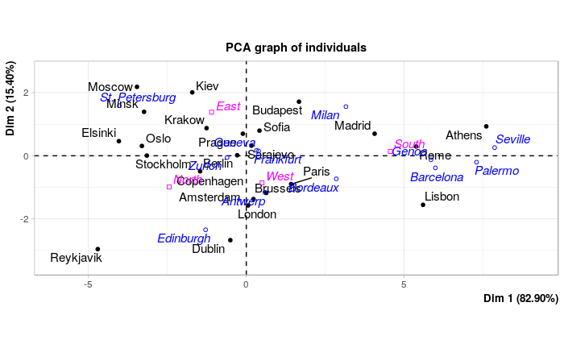

```r
plot.PCA(res,choix="ind")
```

La variable supplémentaire `Area` (colonne 17) pourrait permettre d’interpréter les axes. On peut colorier les différents individus en fonction de la valeur de cette variable :

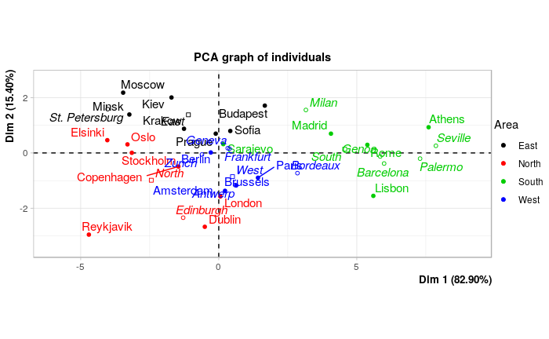

```r
plot.PCA(res,choix="ind",habillage=17)
```

**1. Comment interpréter les deux premiers axes au vu de ces résultats ? Autrement dit qu’est-ce qui oppose les individus aux extrémités de chacun des axes ?**

> L’axe horizontal représente la localisation Nord-Sud des villes européennes. L’axe vertical représente la répartition Ouest-Est des villes européennes. Les individus aux extrémités des axes sont séparés par un aspect géographique qui se traduit également en termes de différences de températures moyennes.

```r
dimdesc(res)
```

```
$Dim.1
$quanti
          correlation      p.value
Annual      0.9975483 9.575809e-26
October     0.9916246 3.734359e-20
September   0.9856254 1.056964e-17
April       0.9738876 5.295583e-15
November    0.9523567 2.659701e-12
March       0.9450521 1.151422e-11
August      0.9092443 1.904695e-09
February    0.8842848 2.180620e-08
December    0.8731191 5.450923e-08
May         0.8698517 7.013036e-08
July        0.8441626 4.129012e-07
January     0.8424506 4.594275e-07
June        0.8333141 7.957991e-07
Latitude   -0.9099106 1.768178e-09

$quali
            R2      p.value
Area 0.6787608 6.282082e-05

$category
            Estimate      p.value
Area=South  4.182744 2.359137e-05
Area=North -2.822709 1.241529e-02

attr(,"class")
[1] "condes" "list "

$Dim.2
$quanti
          correlation      p.value
Amplitude   0.9444140 1.296159e-11
Longitude   0.6449726 8.912273e-04
June        0.5453220 7.119942e-03
July        0.5086619 1.319151e-02
May         0.4578116 2.804268e-02
February   -0.4558325 2.881655e-02
December   -0.4728656 2.268397e-02
```

[output cut: 23 more lines]

```

attr(,"class")
[1] "condes" "list "

$call
$call$num.var
[1] 1

$call$proba
[1] 0.05

$call$weights
 [1] 1 1 1 1 1 1 1 1 1 1 1 1 1 1 1 1 1 1 1 1 1 1 1

$call$X
```

|  | Dim.1 | January | February | March | April | May | June | July | August | September | October | November | December | Annual | Amplitude | Latitude | Longitude | Area |
| --- | --- | --- | --- | --- | --- | --- | --- | --- | --- | --- | --- | --- | --- | --- | --- | --- | --- | --- |
| Amsterdam | 0.22693852 | 2.9 | 2.5 | 5.7 | 8.2 | 12.5 | 14.8 | 17.1 | 17.1 | 14.5 | 11.4 | 7.0 | 4.4 | 9.9 | 14.6 | 52.2 | 4.5 | Area=West |
| Athens | 7.60067204 | 9.1 | 9.7 | 11.7 | 15.4 | 20.1 | 24.5 | 27.4 | 27.2 | 23.8 | 19.2 | 14.6 | 11.0 | 17.8 | 18.3 | 37.6 | 23.5 | Area=South |
| Berlin | -0.28785832 | -0.2 | 0.1 | 4.4 | 8.2 | 13.8 | 16.0 | 18.3 | 18.0 | 14.4 | 10.0 | 4.2 | 1.2 | 9.1 | 18.5 | 52.3 | 13.2 | Area=West |
| Brussels | 0.63117358 | 3.3 | 3.3 | 6.7 | 8.9 | 12.8 | 15.6 | 17.8 | 17.8 | 15.0 | 11.1 | 6.7 | 4.4 | 10.3 | 14.4 | 50.5 | 4.2 | Area=West |
| Budapest | 1.66802839 | -1.1 | 0.8 | 5.5 | 11.6 | 17.0 | 20.2 | 22.0 | 21.3 | 16.9 | 11.3 | 5.1 | 0.7 | 10.9 | 23.1 | 47.3 | 19.0 | Area=East |
| Copenhagen | -1.46239513 | -0.4 | -0.4 | 1.3 | 5.8 | 11.1 | 15.4 | 17.1 | 16.6 | 13.3 | 8.8 | 4.1 | 1.3 | 7.8 | 17.5 | 55.4 | 12.3 | Area=North |
| Dublin | -0.50524137 | 4.8 | 5.0 | 5.9 | 7.8 | 10.4 | 13.3 | 15.0 | 14.6 | 12.7 | 9.7 | 6.7 | 5.4 | 9.3 | 10.2 | 53.2 | 6.1 | Area=North |
| Elsinki | -4.03629712 | -5.8 | -6.2 | -2.7 | 3.1 | 10.2 | 14.0 | 17.2 | 14.9 | 9.7 | 5.2 | 0.1 | -2.3 | 4.8 | 23.4 | 60.1 | 25.0 | Area=North |
| Kiev | -1.71222008 | -5.9 | -5.0 | -0.3 | 7.4 | 14.3 | 17.8 | 19.4 | 18.5 | 13.7 | 7.5 | 1.2 | -3.6 | 7.1 | 25.3 | 50.3 | 30.3 | Area=East |
| Krakow | -1.25865727 | -3.7 | -2.0 | 1.9 | 7.9 | 13.2 | 16.9 | 18.4 | 17.6 | 13.7 | 8.6 | 2.6 | -1.7 | 7.7 | 22.1 | 50.0 | 19.6 | Area=East |

[output cut: 13 more lines]

[output not shown]

**2. Quelles sont les variables les plus corrélées à la composante 1 ? à la composante 2 ?**

```r
res$var$cor
```

```
              Dim.1       Dim.2         Dim.3         Dim.4        Dim.5
January   0.8424506 -0.53135762  6.776712e-02  1.168876e-02  0.031619528
February  0.8842848 -0.45583250 -3.466272e-03  8.371472e-02  0.043624508
March     0.9450521 -0.28731281 -1.207952e-01  7.781832e-02 -0.043317269
April     0.9738876  0.09956500 -1.982562e-01  2.486767e-02  0.016577380
May       0.8698517  0.45781159 -1.560861e-01 -7.682512e-02  0.031288335
June      0.8333141  0.54532195  4.954763e-02  9.575733e-05  0.058509054
July      0.8441626  0.50866195  1.536892e-01  4.360395e-02  0.003553866
August    0.9092443  0.40192442  8.750079e-02  4.439218e-02 -0.036429060
September 0.9856254  0.15253617  2.262618e-02  5.193042e-03 -0.043630460
October   0.9916246 -0.08476471 -6.661858e-05 -7.173534e-02 -0.059633790
November  0.9523567 -0.28941418  4.422075e-02 -6.973744e-02 -0.002706470
December  0.8731191 -0.47286559  8.480816e-02 -6.829538e-02  0.021123796
```

> Les variables les plus corrélées à la composante 1 sont celles ayant les plus grandes valeurs (en valeur absolue) Dim.1.

**3. Quelle est la part de variance expliquée par les 2 premières composantes ? est-il utile de considérer les composantes suivantes pour ce jeu de données ?**

```r
res$eig
```

```
          eigenvalue percentage of variance cumulative percentage of variance
comp 1  9.9477504204           82.897920170                          82.89792
comp 2  1.8476485015           15.397070846                          98.29499
comp 3  0.1262558038            1.052131698                          99.34712
comp 4  0.0382934463            0.319112052                          99.66623
comp 5  0.0167094089            0.139245074                          99.80548
comp 6  0.0128330357            0.106941964                          99.91242
comp 7  0.0058302931            0.048585776                          99.96101
comp 8  0.0020318929            0.016932441                          99.97794
comp 9  0.0010234516            0.008528764                          99.98647
comp 10 0.0009527707            0.007939756                          99.99441
comp 11 0.0005367834            0.004473195                          99.99888
comp 12 0.0001341917            0.001118264                         100.00000
```

> 83% et 15%. Il est inutile de considérer les autres composantes pour ce jeu de données puisque les deux premières donnent plus de 98% du total de variances cumulées.

*Remarque : Le permier axe est bien associé à la plus grande valeur propre.*

Les résultats numériques (coordonnées des projections, corrélations au carré, contributions) pour les individus actifs, c.a.d. ceux ayant participé à l’analyse, sont stockés dans l’élément `ind` de la liste. On pourra afficher le graphe des individus actifs comme ceci :

4. Donnez deux capitales représentatives de l’axe 1, à l’opposé sur l’axe. Considérer les contributions (ou les $cos^2$) et repérer deux villes ayant des coordonnées de signes opposés.

> On peut prendre Athènes et Elsinky pour l’axe 1. Dublin et Kiev pour l’axe 2.

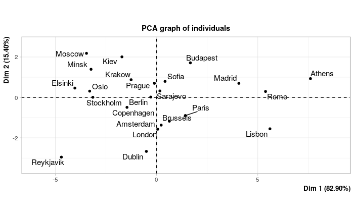

```r
plot.PCA(res, choix = c("ind"),
invisible=c("ind.sup", "quali", "quanti.sup"))
```

5. Procédez de même avec les individus supplémentaires (qui ont le rôle de données de validation), c.a.d. les villes n’étant pas des capitales.

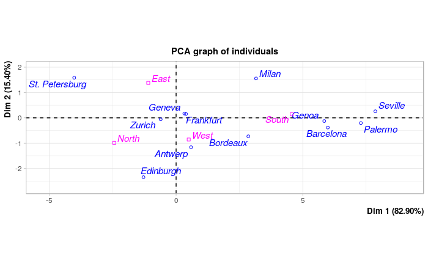

```r
plot.PCA(res, choix = c("ind"), invisible = c("ind"))
```

```r
res$ind.sup
```

```
$coord
                     Dim.1       Dim.2      Dim.3       Dim.4       Dim.5
Antwerp          0.5892648 -1.16201065 -0.1268013 -0.15603707 -0.11613304
Barcelona        5.9892460 -0.38329986  0.2505959  0.02163510 -0.01454736
Bordeaux         2.8501570 -0.73131707 -0.2667125  0.18408602  0.11160661
Edinburgh       -1.2889857 -2.34463780 -0.1810518  0.12244903  0.13465543
Frankfurt        0.3890032  0.15364874 -0.4425226  0.16392128  0.21806343
Geneva           0.3248580  0.17052566 -0.2552736  0.26348373  0.11926130
Genoa            5.8482798 -0.12707972  0.3435118 -0.07839203 -0.22166243
Milan            3.1561321  1.55567808 -0.2462565  0.36059254  0.03288711
Palermo          7.2922522 -0.20543700 -0.5933018 -0.56911196  0.84223935
Seville          7.8644835  0.25777733  0.2165506  0.10684270 -0.03926325
St. Petersburg  -4.0229276  1.58587572  0.8134942  0.01896794 -0.32255205
Zurich          -0.6082877 -0.05761394 -0.3660439  0.23729991  0.03837778

$cos2
                    Dim.1        Dim.2        Dim.3        Dim.4        Dim.5
Antwerp         0.1954400 0.7599985442 0.0090498201 1.370402e-02 7.591090e-03
Barcelona       0.9938250 0.0040704547 0.0017398563 1.296831e-05 5.863191e-06
Bordeaux        0.9233629 0.0607919740 0.0080857757 3.851913e-03 1.415842e-03
Edinburgh       0.2296285 0.7597680759 0.0045303838 2.072241e-03 2.505978e-03
Frankfurt       0.3296074 0.0514219671 0.4265416849 5.852768e-02 1.035753e-01
Geneva          0.3639175 0.1002755755 0.2247125471 2.393995e-01 4.904726e-02
Genoa           0.9933376 0.0004690218 0.0034270781 1.784779e-04 1.427003e-03
Milan           0.7906782 0.1921006780 0.0048135431 1.032103e-02 8.585011e-05
Palermo         0.9689404 0.0007690083 0.0064139430 5.901591e-03 1.292542e-02
Seville         0.9975864 0.0010717650 0.0007563603 1.841195e-04 2.486466e-05
St. Petersburg  0.8295199 0.1289082379 0.0339196473 1.844093e-05 5.332637e-03
Zurich          0.6401597 0.0057428226 0.2318123420 9.742387e-02 2.548179e-03

$dist
       Antwerp       Barcelona        Bordeaux       Edinburgh       Frankfurt
      1.3329189       6.0078239       2.9660781       2.6898945       0.6775708
        Geneva           Genoa           Milan         Palermo         Seville
      0.5385080       5.8678595       3.5494028       7.4082076       7.8739915
St. Petersburg          Zurich
      4.4170144       0.7602648
```

Pour tracer le cercle des corrélations :

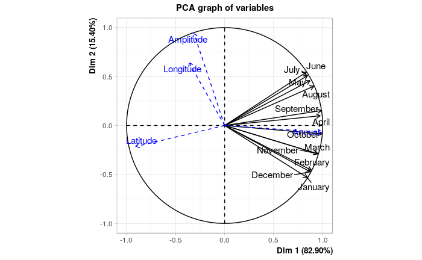

```r
plot.PCA(res, choix = "var")
```

```r
res$var
```

```
$coord
              Dim.1       Dim.2         Dim.3         Dim.4        Dim.5
January   0.8424506 -0.53135762  6.776712e-02  1.168876e-02  0.031619528
February  0.8842848 -0.45583250 -3.466272e-03  8.371472e-02  0.043624508
March     0.9450521 -0.28731281 -1.207952e-01  7.781832e-02 -0.043317269
April     0.9738876  0.09956500 -1.982562e-01  2.486767e-02  0.016577380
May       0.8698517  0.45781159 -1.560861e-01 -7.682512e-02  0.031288335
June      0.8333141  0.54532195  4.954763e-02  9.575733e-05  0.058509054
July      0.8441626  0.50866195  1.536892e-01  4.360395e-02  0.003553866
August    0.9092443  0.40192442  8.750079e-02  4.439218e-02 -0.036429060
September 0.9856254  0.15253617  2.262618e-02  5.193042e-03 -0.043630460
October   0.9916246 -0.08476471 -6.661858e-05 -7.173534e-02 -0.059633790
November  0.9523567 -0.28941418  4.422075e-02 -6.973744e-02 -0.002706470
December  0.8731191 -0.47286559  8.480816e-02 -6.829538e-02  0.021123796

$cor
              Dim.1       Dim.2         Dim.3         Dim.4        Dim.5
January   0.8424506 -0.53135762  6.776712e-02  1.168876e-02  0.031619528
February  0.8842848 -0.45583250 -3.466272e-03  8.371472e-02  0.043624508
March     0.9450521 -0.28731281 -1.207952e-01  7.781832e-02 -0.043317269
April     0.9738876  0.09956500 -1.982562e-01  2.486767e-02  0.016577380
May       0.8698517  0.45781159 -1.560861e-01 -7.682512e-02  0.031288335
June      0.8333141  0.54532195  4.954763e-02  9.575733e-05  0.058509054
July      0.8441626  0.50866195  1.536892e-01  4.360395e-02  0.003553866
August    0.9092443  0.40192442  8.750079e-02  4.439218e-02 -0.036429060
September 0.9856254  0.15253617  2.262618e-02  5.193042e-03 -0.043630460
October   0.9916246 -0.08476471 -6.661858e-05 -7.173534e-02 -0.059633790
November  0.9523567 -0.28941418  4.422075e-02 -6.973744e-02 -0.002706470
December  0.8731191 -0.47286559  8.480816e-02 -6.829538e-02  0.021123796

$cos2
              Dim.1       Dim.2        Dim.3        Dim.4        Dim.5
January   0.7097230 0.282340915 4.592383e-03 1.366271e-04 9.997946e-04
February  0.7819596 0.207783268 1.201504e-05 7.008155e-03 1.903098e-03
March     0.8931235 0.082548649 1.459148e-02 6.055690e-03 1.876386e-03
April     0.9484570 0.009913188 3.930551e-02 6.184011e-04 2.748095e-04
May       0.7566419 0.209591455 2.436286e-02 5.902099e-03 9.789599e-04
June      0.6944124 0.297376030 2.454967e-03 9.169466e-09 3.423309e-03
July      0.7126106 0.258736979 2.362036e-02 1.901305e-03 1.262996e-05
August    0.8267252 0.161543240 7.656389e-03 1.970666e-03 1.327076e-03
September 0.9714575 0.023267284 5.119442e-04 2.696769e-05 1.903617e-03
October   0.9833194 0.007185057 4.438035e-09 5.145958e-03 3.556189e-03
November  0.9069833 0.083760565 1.955475e-03 4.863310e-03 7.324982e-06
December  0.7623370 0.223601871 7.192425e-03 4.664259e-03 4.462148e-04

$contrib
             Dim.1      Dim.2        Dim.3        Dim.4       Dim.5
January   7.134508 15.2810946 3.637364e+00 3.567898e-01  5.98342273
February  7.860668 11.2458224 9.516430e-03 1.830119e+01 11.38937776
March     8.978146  4.4677680 1.155707e+01 1.581391e+01 11.22951624
April     9.534387  0.5365300 3.113164e+01 1.614901e+00  1.64463940
May       7.606161 11.3436865 1.929643e+01 1.541282e+01  5.85873440
June      6.980597 16.0948378 1.944439e+00 2.394526e-05 20.48731569
July      7.163535 14.0035823 1.870833e+01 4.965091e+00  0.07558593
August    8.310674  8.7431803 6.064187e+00 5.146222e+00  7.94209075
September 9.765600  1.2592917 4.054817e-01 7.042377e-02 11.39248596
October   9.884842  0.3888757 3.515114e-06 1.343822e+01 21.28255345
November  9.117472  4.5333604 1.548820e+00 1.270011e+01  0.04383747
December  7.663411 12.1019702 5.696708e+00 1.218030e+01  2.67044021
```

> - Axe 1 : corrélé à la température moyenne annuelle et la latitude
> - Axe 2 : corrélé à l’amplitude des températures et la longitude
6. Quels sont les mois contribuant le plus à l’inertie sur l’axe 1 ? sur l’axe 2 ? **N.B.** Dans le package on utilise la convention $||a|| = \sqrt\lambda$, les contributions sont donc les carrés des coordonnées, divisés par la valeur propre de l’axe.

#### **Exercice 2** (Analyse des correspondances).

On utilise les données `JO` . Les lignes correspondent à des disciplines olympiques, les colonnes à des pays. Chaque cellule contient le nombre de médailles (or/argent/bronze) gagnées par un pays entre 92 et 2008 (5 jeux, donc 15 médailles par discipline). On a bien une table de contingence (creuse) obtenue à partir de données originales binaires où chaque ligne correspond à une médaille, avec deux « 1 » par lignes (pays concerné et discipline), les cellules restantes valant 0. Il y a 24 disciplines. Pour charger la table de contingence et afficher la description des données :

```r
data(JO)
?JO
```

On vérifie qu’il y a bien 15 médailles par discipline :

```r
apply(JO, 1, sum)
```

```
      10000m         100m        110mH        1500m         200m         20km 3000mSteeple         400m
          15           15           15           15           15           15           15           15
       400mH       4x100m       4x400m        5000m         50km         800m    Decathlon       Disque
          15           15           15           15           15           15           15           15
     Hauteur      Javelot     Longueur     Marathon      Marteau       Perche        Poids  Triple saut
          15           15           15           15           15           15           15           15
```

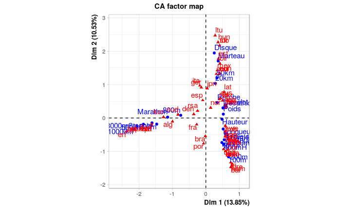

```r
resJO <- CA(JO)
```

```r
summary(resJO)
```

```
Call:
CA(X = JO)

The chi square of independence between the two variables is equal to 2122.231 (p-value =  2.320981e-41 ).

Eigenvalues
                       Dim.1   Dim.2   Dim.3   Dim.4   Dim.5   Dim.6   Dim.7   Dim.8   Dim.9  Dim.10
Variance               0.817   0.621   0.544   0.481   0.396   0.364   0.327   0.315   0.269   0.245
% of var.             13.854  10.529   9.232   8.162   6.721   6.174   5.554   5.351   4.560   4.156
Cumulative % of var.  13.854  24.383  33.615  41.778  48.499  54.673  60.226  65.577  70.137  74.293
                      Dim.11  Dim.12  Dim.13  Dim.14  Dim.15  Dim.16  Dim.17  Dim.18  Dim.19  Dim.20
Variance               0.230   0.183   0.164   0.145   0.131   0.121   0.103   0.093   0.085   0.079
% of var.              3.910   3.107   2.783   2.457   2.218   2.056   1.756   1.584   1.437   1.347
Cumulative % of var.  78.203  81.310  84.093  86.550  88.767  90.824  92.579  94.164  95.601  96.948
                      Dim.21  Dim.22  Dim.23
Variance               0.075   0.062   0.043
% of var.              1.266   1.052   0.734
Cumulative % of var.  98.214  99.266 100.000

Rows (the 10 first)
               Iner*1000     Dim.1     ctr    cos2     Dim.2     ctr    cos2     Dim.3     ctr    cos2
10000m       |   366.587 |  -2.162  23.850   0.531 |  -0.330   0.730   0.012 |  -0.172   0.227   0.003
100m         |   262.733 |   0.678   2.347   0.073 |  -1.164   9.093   0.215 |  -0.407   1.267   0.026
110mH        |   157.044 |   0.593   1.795   0.093 |  -0.498   1.665   0.066 |  -0.395   1.196   0.041
1500m        |   338.175 |  -1.469  11.016   0.266 |  -0.185   0.229   0.004 |   0.373   1.067   0.017
200m         |   199.995 |   0.716   2.612   0.107 |  -1.084   7.889   0.245 |  -0.468   1.679   0.046
20km         |   330.785 |   0.284   0.411   0.010 |   1.037   7.213   0.135 |   1.476  16.677   0.274
3000mSteeple |   271.032 |  -1.610  13.230   0.399 |  -0.147   0.146   0.003 |   0.127   0.123   0.002
400m         |   137.131 |   0.480   1.177   0.070 |  -0.736   3.639   0.165 |  -0.312   0.746   0.030
400mH        |   265.578 |   0.532   1.444   0.044 |  -0.785   4.137   0.097 |  -0.406   1.265   0.026
4x100m       |   202.241 |   0.550   1.542   0.062 |  -0.654   2.870   0.088 |  -0.397   1.204   0.032

10000m       |
100m         |
110mH        |
1500m        |
200m         |
20km         |
3000mSteeple |
400m         |
```

[output cut: 11 more lines]

```
bra          |   102.778 |  -0.016   0.000   0.000 |  -0.543   0.395   0.024 |  -0.516   0.408   0.022
brn          |    63.889 |  -1.626   0.899   0.115 |  -0.234   0.025   0.002 |   0.506   0.131   0.011
can          |    55.556 |   0.582   0.461   0.068 |  -0.406   0.295   0.033 |   0.094   0.018   0.002
chn          |    63.889 |   0.656   0.147   0.019 |  -0.632   0.179   0.017 |  -0.536   0.147   0.012

alg          |
aus          |
bah          |
bar          |
bdi          |
blr          |
bra          |
brn          |
can          |
chn          |
```

Le test du $χ^2$ rejette largement l’indépendance mais la $p$-valeur ne doit pas être prise au pied de la lettre : la condition $n_{ij} > 5$ pour toute paire $(i, j)$ n’est pas satisfaite. Pour obtenir les profils lignes et colonnes de la table :

```r
## profils lignes
rowprof <- JO / apply(JO, 1, sum)
apply(rowprof,1,sum)
```

```
      10000m         100m        110mH        1500m         200m         20km 3000mSteeple         400m
           1            1            1            1            1            1            1            1
       400mH       4x100m       4x400m        5000m         50km         800m    Decathlon       Disque
           1            1            1            1            1            1            1            1
     Hauteur      Javelot     Longueur     Marathon      Marteau       Perche        Poids  Triple saut
           1            1            1            1            1            1            1            1
```

```r
## profils colonnes
colprof <- t(t(JO) / apply(JO, 2, sum)) #t() : transposee
apply(colprof,2,sum)
```

```
alg aus bah bar bdi blr bra brn can chn cub cze den dom ecu eri esp est eth eun fin fra gbr ger gre hun
  1   1   1   1   1   1   1   1   1   1   1   1   1   1   1   1   1   1   1   1   1   1   1   1   1   1
ita jam jpn kaz ken kor ksa lat ltu mar mex nam ngr nor nzl pan pol por qat rou rsa rus slo sud swe tch
  1   1   1   1   1   1   1   1   1   1   1   1   1   1   1   1   1   1   1   1   1   1   1   1   1   1
tri tur uga ukr usa zam
  1   1   1   1   1   1
```

1. Inspectez les valeurs propres de l’AC. Combien faudrait-il garder de dimensions pour expliquer 50% de la variance ?

```r
round(resJO$eig,1)
```

```
       eigenvalue percentage of variance cumulative percentage of variance
dim 1         0.8                   13.9                              13.9
dim 2         0.6                   10.5                              24.4
dim 3         0.5                    9.2                              33.6
dim 4         0.5                    8.2                              41.8
dim 5         0.4                    6.7                              48.5
dim 6         0.4                    6.2                              54.7
dim 7         0.3                    5.6                              60.2
dim 8         0.3                    5.4                              65.6
dim 9         0.3                    4.6                              70.1
dim 10        0.2                    4.2                              74.3
dim 11        0.2                    3.9                              78.2
dim 12        0.2                    3.1                              81.3
dim 13        0.2                    2.8                              84.1
dim 14        0.1                    2.5                              86.5
dim 15        0.1                    2.2                              88.8
dim 16        0.1                    2.1                              90.8
dim 17        0.1                    1.8                              92.6
dim 18        0.1                    1.6                              94.2
dim 19        0.1                    1.4                              95.6
dim 20        0.1                    1.3                              96.9
dim 21        0.1                    1.3                              98.2
dim 22        0.1                    1.1                              99.3
dim 23        0.0                    0.7                             100.0
```

> On constate donc qu’il faudrait garder 6 dimensions pour expliquer 50% de la variance.
2. Vérifiez que l’inertie totale vaut $1/n \times$ la statistique du $χ^2$. On accède directement à cette dernière via la fonction `chisq.test`.

```r
chisq.test(JO)
```

```
l'approximation du Chi-2 est peut-être incorrecte
```

```
    Pearson's Chi-squared test

data:  JO
X-squared = 2122.2, df = 1311, p-value < 2.2e-16
```

> On voit donc que les valeurs ne sont pas indépendantes.
3. Les coordonnées des profils lignes sur les axes principaux sont accessibles via

```r
resJO$row$coord
```

```
                  Dim 1       Dim 2       Dim 3        Dim 4       Dim 5
10000m       -2.1621177 -0.32982549 -0.17204577  0.081633874  0.55486198
100m          0.6783149 -1.16388948 -0.40688358 -0.332956787 -0.12331848
110mH         0.5931714 -0.49798366 -0.39525262 -0.053903841 -0.25834929
1500m        -1.4694381 -0.18472477  0.37332390 -0.196623725 -0.69096273
200m          0.7155408 -1.08408289 -0.46829289 -0.211556635  0.01916550
20km          0.2838737  1.03661465  1.47590265 -1.515023258 -0.82420805
3000mSteeple -1.6103379 -0.14740343  0.12688933 -0.090885749 -0.15233215
400m          0.4802545 -0.73624878 -0.31218478 -0.056116610  0.04682458
400mH         0.5320823 -0.78505635 -0.40642826 -0.068597697 -0.03721406
4x100m        0.5497460 -0.65390541 -0.39651100 -0.263291744  0.19379449
4x400m        0.6595150 -0.59592831  0.06796214 -0.129165251 -0.09757978
5000m        -1.8671256 -0.18726132 -0.08846354  0.135515200  0.05999955
50km          0.3318944  1.20030297  1.17299464 -0.747038891 -0.26773101
800m         -0.7509634  0.07984624  0.15379693  0.539658031 -0.23351758
Decathlon     0.5120847  0.30133685 -0.08254275  1.032463527 -0.15580067
Disque        0.2517965  1.94790027 -1.79326276  1.115289280 -1.49007590
Hauteur       0.4839793 -0.03760759  0.57031734  0.266455666 -0.20350760
Javelot       0.5716717  0.32186729  1.75954398  2.120987135  1.00826615
Longueur      0.5191249 -0.33019534 -0.21180289 -0.269505397 -0.16562749
Marathon     -1.1433486  0.02533805 -0.34884371 -0.134101840  0.40994637
Marteau       0.3712894  1.70731438 -1.08423488 -0.834993960  1.95647718
Perche        0.3396610  0.46204966  0.26312975 -0.605913722  0.16348719
Poids         0.5229643  0.11540302 -0.25192644  0.005747727  0.57077733
Triple saut   0.6063664 -0.46386058  0.45481520  0.211924666 -0.28337554
```

Vérifiez que le barycentre des projections des profils lignes sur les deux premiers axes est le vecteur nul, lorsque l’on utilise comme poids les fréquences marginales, obtenues comme ceci :

```r
n <- sum(JO)
rowW <- apply(JO,1,sum)/n
rowW
```

```
      10000m         100m        110mH        1500m         200m         20km 3000mSteeple         400m
  0.04166667   0.04166667   0.04166667   0.04166667   0.04166667   0.04166667   0.04166667   0.04166667
       400mH       4x100m       4x400m        5000m         50km         800m    Decathlon       Disque
  0.04166667   0.04166667   0.04166667   0.04166667   0.04166667   0.04166667   0.04166667   0.04166667
     Hauteur      Javelot     Longueur     Marathon      Marteau       Perche        Poids  Triple saut
  0.04166667   0.04166667   0.04166667   0.04166667   0.04166667   0.04166667   0.04166667   0.04166667
```

```r
colW <- apply(JO,2,sum)/n
colW
```

```
        alg         aus         bah         bar         bdi         blr         bra         brn
0.011111111 0.016666667 0.008333333 0.002777778 0.002777778 0.016666667 0.008333333 0.002777778
        can         chn         cub         cze         den         dom         ecu         eri
0.011111111 0.002777778 0.038888889 0.016666667 0.008333333 0.002777778 0.005555556 0.002777778
        esp         est         eth         eun         fin         fra         gbr         ger
0.022222222 0.008333333 0.041666667 0.019444444 0.011111111 0.008333333 0.041666667 0.027777778
        gre         hun         ita         jam         jpn         kaz         ken         kor
0.002777778 0.008333333 0.019444444 0.025000000 0.011111111 0.002777778 0.097222222 0.005555556
        ksa         lat         ltu         mar         mex         nam         ngr         nor
0.002777778 0.008333333 0.011111111 0.027777778 0.011111111 0.011111111 0.011111111 0.008333333
        nzl         pan         pol         por         qat         rou         rsa         rus
0.002777778 0.002777778 0.022222222 0.008333333 0.002777778 0.002777778 0.016666667 0.052777778
        slo         sud         swe         tch         tri         tur         uga         ukr
0.002777778 0.002777778 0.008333333 0.005555556 0.016666667 0.002777778 0.002777778 0.013888889
        usa         zam
0.227777778 0.002777778
```

> On constate que chaque épreuve à la même valeur de projeté de barycentre. Cela peut s’expliquer par le fait que chaque discipline décerne 3 médailles à chaque fois. De même, on remarque que les USA ont un projeté très grand, indiquant un nombre de médailles gagnées important.
4. Vérifiez que la variance pondérée des coordonnées des lignes sur le premier axe est égale à la première valeur propre.